# Introduction to Regression: A Real Example

Homework Deadlines and Student Performance

Author

Tanja

Published

March 13, 2026

## 1 Learning Objectives

By the end of this lecture you should be able to:

- identify a suitable **response** and **explanatory** variable for a simple regression model
- visualise a relationship using a **scatterplot**
- fit and interpret a **simple linear regression model** in R
- explain the meaning of the **regression line** and **residuals**
- interpret the coefficient of determination, $R^2$
- assess whether a relationship is **statistically significant**
- use a fitted regression model to make simple predictions

## 2 Lecture Overview

In this lecture we will cover:

- the study behind the data
- loading and exploring the homework dataset
- choosing variables for a regression model
- scatterplots and first impressions of the relationship
- fitting a regression line in R
- residuals and model fit
- explained and unexplained variation
- the coefficient of determination, $R^2$
- testing for the existence of a relationship
- making predictions from the fitted model
- the ANOVA table

## 3 A Real Example

So far we have discussed the ideas behind regression in general terms.

To make these ideas more concrete, we now turn to a real dataset taken from a published study. Working with real data helps us see how regression modelling is used in practice and how the main ideas from the previous lecture are applied step by step.

## 4 The Study Behind the Data

The dataset used in this lecture comes from the following study:

Smith, C. (2025). *The Impact of Homework Deadline Times on College Student Performance and Stress: A Quasi-Experiment in Business Statistics*. Journal of Statistics and Data Science Education, 33(3), 334–343. https://doi.org/10.1080/26939169.2024.2441692

The study investigates whether the timing of homework deadlines affects student performance and stress levels.

Researchers collected data from students enrolled in a statistics course and compared outcomes under different homework deadline policies.

You are not expected to read the full paper for this lecture, but it provides useful context for the dataset we will analyse.

## 5 Why Study Relationships?

Many questions in statistics involve understanding relationships between variables.

For example:

- does study time affect exam performance?
- does advertising affect sales?
- does the timing of homework deadlines affect student outcomes?

Regression analysis helps us quantify these relationships.

In this lecture we will explore these ideas using the homework deadline dataset.

## 6 Loading the Homework Dataset

```r
library(dplyr)
hw <- read.csv("https://raw.githubusercontent.com/TanjaKec/mydata/master/HW_R.csv")

glimpse(hw)
```

```
Rows: 85
Columns: 24
$ ID                 <int> 1001, 1002, 1003, 1004, 1005, 1006, 1007, 1008, 100…
$ HW_minutes         <int> 673, 394, 943, 334, 976, 551, 1096, 514, 1886, 755,…
$ Midnight_deadline  <int> 1, 0, 0, 0, 1, 0, 0, 1, 0, 1, 1, 0, 0, 1, 1, 0, 0, …
$ Fall_semester      <int> 1, 1, 1, 0, 0, 0, 1, 1, 0, 1, 0, 0, 0, 1, 1, 0, 1, …
$ Female             <int> 1, 0, 0, 0, 1, 0, 1, 0, 0, 0, 1, 0, 1, 0, 0, 0, 0, …
$ Section            <int> 21, 22, 22, 11, 12, 11, 22, 21, 11, 21, 12, 11, 11,…
$ Year_in_school     <int> 2, 4, 3, 2, 2, 4, 2, 3, 3, 2, 3, 3, 3, 2, 2, 2, 3, …
$ GPA                <dbl> 3.930, 3.640, 3.260, 3.625, 3.804, 3.063, 3.220, 3.…
$ ACT                <chr> "33", "N/A", "N/A", "28", "28", "22", "22", "26", "…
$ Major_BA           <int> 0, 0, 0, 0, 0, 0, 0, 0, 0, 0, 0, 0, 0, 1, 0, 0, 0, …
$ Major_Finance      <int> 0, 1, 1, 0, 0, 1, 0, 0, 1, 0, 0, 0, 0, 0, 1, 0, 1, …
$ Major_Accounting   <int> 1, 0, 0, 0, 0, 0, 0, 0, 0, 0, 1, 0, 1, 0, 0, 0, 0, …
$ Major_Marketing    <int> 0, 0, 0, 1, 1, 0, 1, 0, 0, 0, 0, 1, 0, 0, 0, 1, 0, …
$ Major_Management   <int> 0, 0, 0, 0, 0, 0, 0, 1, 0, 1, 0, 0, 0, 0, 0, 0, 0, …
$ Major_Sport        <int> 0, 0, 0, 0, 0, 0, 0, 0, 0, 0, 0, 0, 0, 0, 0, 0, 0, …
$ Q1_HW_effective    <int> 5, 5, 4, 3, 4, 4, 2, 5, 4, 5, 3, 4, 4, 5, 3, 2, 5, …
$ Q2_deadline_effect <int> 5, 4, 3, 4, 3, 2, 2, 4, 3, 4, 4, 2, 3, 3, 3, 3, 5, …
$ Q3_deadline_stress <int> 5, 3, 3, 3, 3, 2, 2, 3, 4, 3, 2, 3, 2, 3, 3, 2, 3, …
$ Q4_average_time    <chr> "90", "90", "120", "25", "105", "60", "210", "38", …
$ Q5_preferred_time  <chr> "4", "2", "4", "4", "4", "5", "5", "2", "2", "4", "…
$ Q6_extensions      <chr> "0", "0", "0", "0", "0", "0", "0", "0", "0", "1", "…
$ Q7_late_turnins    <chr> "0", "0", "1.5", "0", "0", "2.5", "0", "0", "0", "0…
$ Grade_course       <dbl> 1.0064580, 0.8718605, 0.8206798, 94.5000000, 94.200…
$ Grade_HW           <dbl> 0.9988415, 0.8642683, 0.7348171, 90.6000000, 92.900…
```

The `glimpse()` function provides a quick overview of the structure of the dataset.

Each row represents a single student observation, while each column represents a variable recorded in the study. The output shows the name of each variable, its data type, and a few example values.

Before carrying out any statistical analysis, it is important to understand what the variables represent and how they might be used in a regression model.

## 7 Understanding the Variables

Several variables in this dataset describe characteristics of the students and their study behaviour.

Some of the key variables include:

- `HW_minutes` – the total number of minutes a student reported spending on homework
- `Midnight_deadline` – an indicator for whether the course used a midnight homework deadline
- `GPA` – the student’s grade point average
- `Grade_course` – the student’s overall course grade
- `Grade_HW` – the student’s homework grade

Other variables record demographic characteristics such as gender, academic major, and year in school.

In regression analysis we typically distinguish between two types of variables:

- a **response variable**, which is the outcome we want to explain
- an **explanatory variable**, which may help explain variation in the response

## 8 Choosing Variables for Analysis

A natural question in the context of this study is whether the amount of time students spend on homework is related to their homework performance.

To explore this idea we begin with:

- **Response variable:** `Grade_HW`
- **Explanatory variable:** `HW_minutes`

Both variables are measured numerically, which makes them suitable for a **simple linear regression model**. Before fitting a regression model, it is useful to first visualise the relationship between the two variables using a scatterplot.

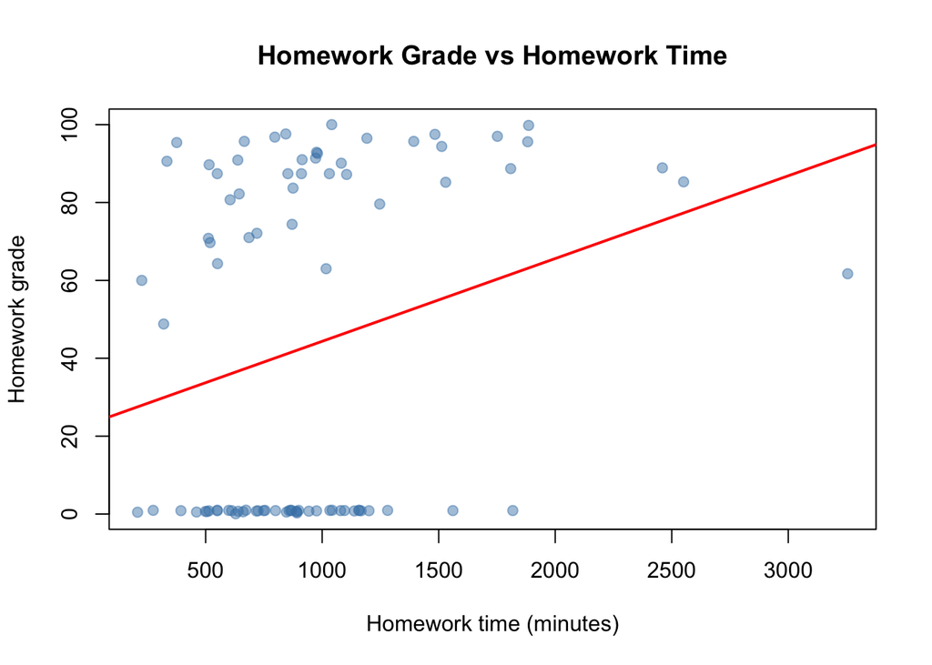

```r
plot(Grade_HW ~ HW_minutes,
     data = hw,
     pch = 19,
     col = rgb(70,130,180,120,maxColorValue = 255),  # transparent steelblue
     xlab = "Homework time (minutes)",
     ylab = "Homework grade",
     main = "Homework Grade vs Homework Time")

abline(lm(Grade_HW ~ HW_minutes, data = hw),
       col = "red",
       lwd = 2)
```

Each point on the graph represents a single student. The horizontal axis shows the amount of time spent on homework, while the vertical axis shows the student’s homework grade.

The red line represents the **line of best fit**, which summarises the overall relationship between homework time and homework performance. In the next section we will see how this line is estimated using regression modelling.

**ImportantYour Turn 👉 Stop and Think 🤔**

Based on the scatterplot, consider the following:

- Does the relationship appear **positive**, **negative**, or **unclear**?
- Do students who spend **more time on homework** tend to achieve **higher grades**?

Take a moment to think about this before continuing.

Visual inspection of the scatterplot gives us an initial idea of whether a relationship may exist between the two variables.

However, visual inspection alone is not sufficient. To analyse the relationship more formally, we now fit a **simple linear regression model**.

## 9 From Scatterplot to Regression

A scatterplot allows us to visually inspect whether a relationship may exist between two variables. However, visual inspection alone is not sufficient.

Regression analysis provides a way to summarise the relationship between two variables using a straight line that best represents the overall pattern in the data.

This line is called the **regression line** or the **line of best fit**.

In simple linear regression, the relationship between the variables is written as

$$Y = \beta_0 + \beta_1 X + e$$

where

**- \(Y\)** is the **response variable**

**- \(X\)** is the **explanatory variable**

**- \(\beta_0\)** is the **intercept**

**- \(\beta_1\)** is the **slope**

**- \(e\)** represents the **influence of other factors not included in the model**

The slope tells us how much the response variable changes when the explanatory variable increases by one unit.

```r
model_hw <- lm(Grade_HW ~ HW_minutes, data = hw)

model_hw
```

```
Call:
lm(formula = Grade_HW ~ HW_minutes, data = hw)

Coefficients:
(Intercept)   HW_minutes
   23.10161      0.02126
```

The `lm()` function in R fits a **linear model**.

In this case, we are estimating the relationship between:

- `Grade_HW` (homework grade)
- `HW_minutes` (time spent on homework)

The output provides estimates of the intercept and the slope of the regression line.

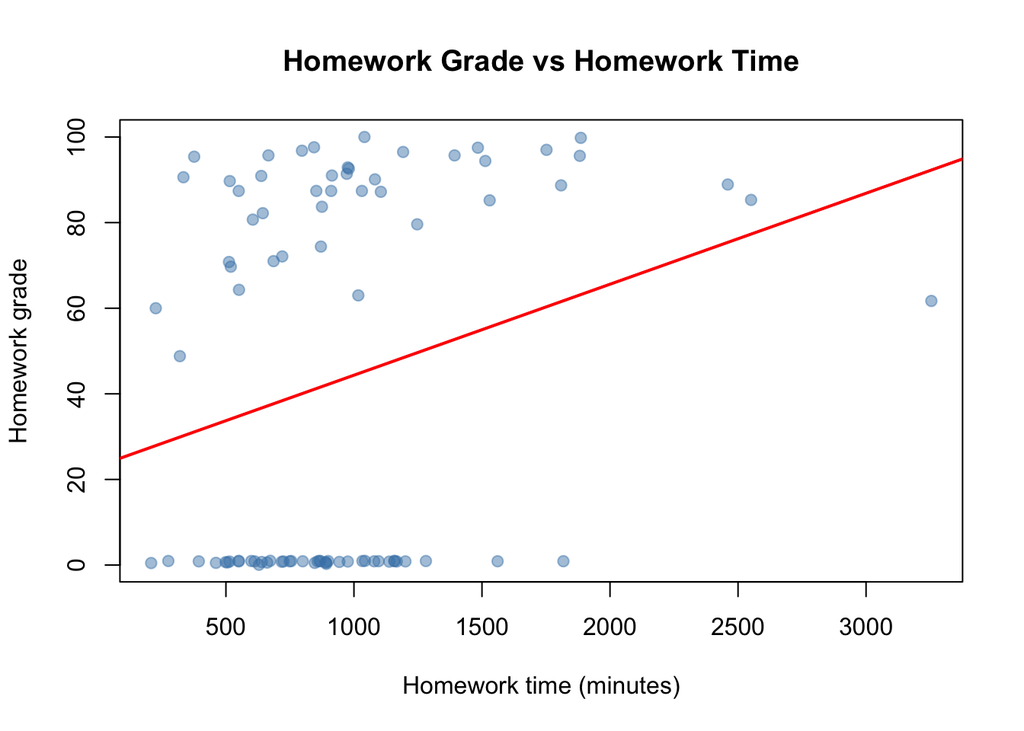

```r
plot(Grade_HW ~ HW_minutes,
     data = hw,
     pch = 19,
     col = rgb(70,130,180,120,maxColorValue = 255),
     xlab = "Homework time (minutes)",
     ylab = "Homework grade",
     main = "Homework Grade vs Homework Time")

abline(model_hw, col = "red", lwd = 2)
```

The red line is the **estimated regression line**.

It summarises the overall relationship between homework time and homework performance. Points above the line represent students who performed **better than predicted**, while points below the line represent students who performed **worse than predicted**.

**TipThink about it**

Does the regression line suggest that spending more time on homework is associated with **higher grades**, **lower grades**, or **no clear relationship**?

## 10 Residuals

When we fit a regression line to the data, not all points lie exactly on the line.

For each observation, the regression model produces a **predicted value** of the response variable. This predicted value is usually written as:

$$\hat{Y}$$

The difference between the observed value and the predicted value is called the **residual**.

$$\text{Residual} = Y - \hat{Y}$$

Residuals measure the vertical distance between each observed data point and the regression line.

```r
hw$fitted <- fitted(model_hw)
hw$residuals <- resid(model_hw)

head(hw[, c("Grade_HW","HW_minutes","fitted","residuals")])
```

```
    Grade_HW HW_minutes   fitted residuals
1  0.9988415        673 37.41022 -36.41138
2  0.8642683        394 31.47842 -30.61415
3  0.7348171        943 43.15067 -42.41585
4 90.6000000        334 30.20276  60.39724
5 92.9000000        976 43.85228  49.04772
6 64.3000000        551 34.81638  29.48362
```

The fitted values (`fitted`) represent the predicted homework grade produced by the regression model.

The residuals measure the difference between the actual grade and the predicted grade.

- A **positive residual** means the student performed **better than predicted**.
- A **negative residual** means the student performed **worse than predicted**.

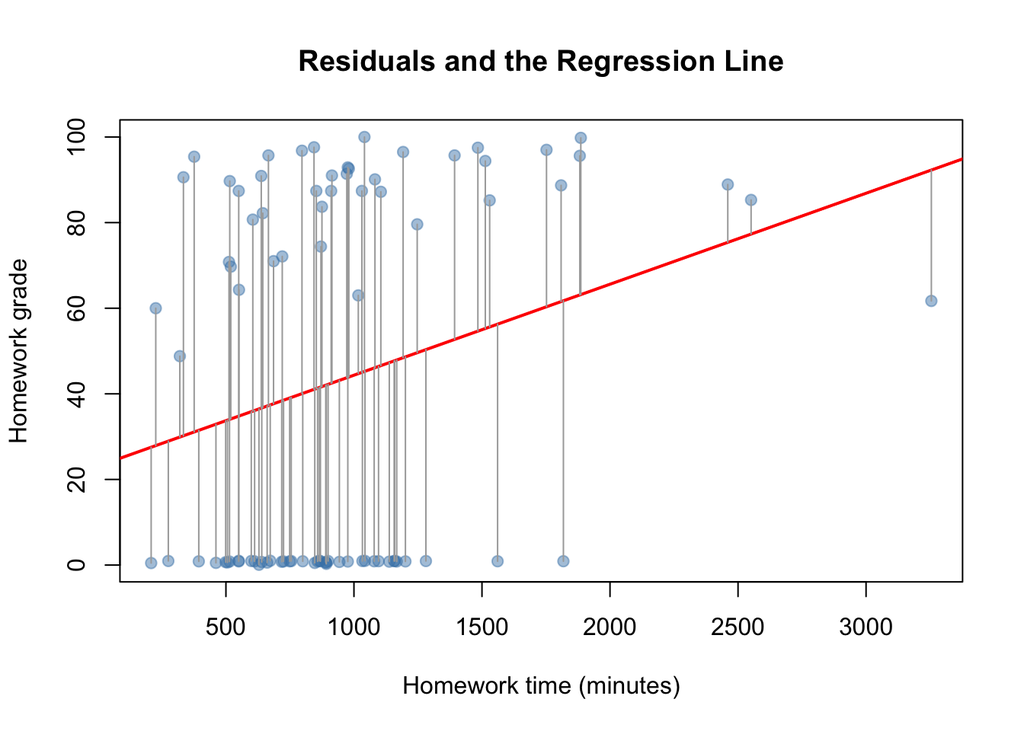

```r
plot(Grade_HW ~ HW_minutes,
     data = hw,
     pch = 19,
     col = rgb(70,130,180,120,maxColorValue = 255),
     xlab = "Homework time (minutes)",
     ylab = "Homework grade",
     main = "Residuals and the Regression Line")

abline(model_hw, col = "red", lwd = 2)

segments(hw$HW_minutes,
         hw$fitted,
         hw$HW_minutes,
         hw$Grade_HW,
         col = "darkgrey")
```

The vertical grey lines show the **residuals**.

Each line represents the difference between the actual value and the value predicted by the regression model.

Shorter residuals indicate that the regression line fits the data more closely.

**TipThink about it**

Do most points lie close to the regression line, or are they widely scattered?

What does this suggest about how well homework time explains variation in homework grades?

## 11 Explained and Unexplained Variation

The total variation in the response variable can be decomposed into two parts:

- **explained variation**, captured by the regression model
- **unexplained variation**, captured by the residuals

This decomposition forms the basis for several important quantities in regression analysis, including the coefficient of determination $R^2$ and the F-test.

Mathematically, this decomposition can be written as

$$\text{Total Variation}
=
\text{Explained Variation}
+
\text{Unexplained Variation}$$

or more specifically

$$\sum (Y - \bar{Y})^2 =
\sum (\hat{Y} - \bar{Y})^2 +
\sum (Y - \hat{Y})^2$$

where

- $Y$ is the observed value
- $\hat{Y}$ is the predicted value from the regression model
- $\bar{Y}$ is the mean of the response variable

In this decomposition:

- $Y - \bar{Y}$ measures how far each observation is from the overall average
- $\hat{Y} - \bar{Y}$ measures the variation explained by the regression model
- $Y - \hat{Y}$ measures the unexplained variation (the residual)

**TipKey idea**

A **good regression model** explains a large portion of the total variation in the response variable.

This means that the residuals will tend to be **small**, because the model closely matches the observed data.

To summarise how much of the total variation is explained by the model, we use the **coefficient of determination**, denoted by $R^2$.

$$\text{Scatterplot} \;\rightarrow\;
\text{Regression Line} \;\rightarrow\;
\text{Residuals} \;\rightarrow\;
\text{Variation} \;\rightarrow\;
R^2$$

We will examine this quantity next.

## 12 The Coefficient of Determination $R^2$

The decomposition of variation leads to an important summary measure in regression analysis: the **coefficient of determination**, denoted by $R^2$.

The coefficient of determination measures the **proportion of the total variation in the response variable that is explained by the regression model**.

It is defined as

$$R^2 =
\frac{\text{Explained Variation}}{\text{Total Variation}}$$

The value of $R^2$ always lies between 0 and 1.

- $R^2 = 0$ indicates that the model explains none of the variation in the response variable.
- $R^2 = 1$ indicates that the model perfectly explains the variation.

In practice, most regression models lie somewhere between these two extremes.

## 13 Obtaining $R^2$ in R

To obtain detailed information about the fitted regression model we use the `summary()` function.

```r
summary(model_hw)
```

```
Call:
lm(formula = Grade_HW ~ HW_minutes, data = hw)

Residuals:
   Min     1Q Median     3Q    Max
-60.86 -40.48 -27.05  42.38  64.30

Coefficients:
             Estimate Std. Error t value Pr(>|t|)
(Intercept) 23.101606   9.630175   2.399   0.0187 *
HW_minutes   0.021261   0.008868   2.398   0.0187 *
---
Signif. codes:  0 '***' 0.001 '**' 0.01 '*' 0.05 '.' 0.1 ' ' 1

Residual standard error: 42.11 on 83 degrees of freedom
Multiple R-squared:  0.06477,   Adjusted R-squared:  0.0535
F-statistic: 5.748 on 1 and 83 DF,  p-value: 0.01875
```

The summary() function provides a detailed statistical summary of the regression model, including:

- the estimated regression coefficients
- the variability of the residuals
- measures of how well the model fits the data
- statistical tests used to evaluate the relationship between the variables

One of the key quantities reported in this output is the coefficient of determination $R^2$.

### 13.1 Interpreting the $R^2$ value

For our regression model the coefficient of determination is

$$R^2 = 0.065$$

This means that approximately 6.5% of the variation in homework grades is explained by the amount of time students spend on homework.

The remaining 93.5% of the variation must be due to other factors that are not included in the model.

**TipPause and think**

Do you think this is a **good model or a poor model**?

Why?

Consider the following:

- the slope coefficient is statistically significant
- the value of $R^2$ is relatively small
- the scatterplot shows substantial variability in grades

What does this suggest about the ability of homework time to explain differences in homework performance?

Although the value of $R^2$ is relatively small, this does **not necessarily mean that the model is useless**.

In studies involving human behaviour and performance, it is common for many different factors to influence the outcome. As a result, simple regression models that include only one explanatory variable often explain only a modest proportion of the overall variation.

In our case, homework time appears to have a measurable relationship with homework grades, but it clearly does **not capture all of the factors that influence student performance**.

The regression model therefore suggests that **time spent on homework is one factor influencing homework grades, but many other factors must also play an important role**.

The value of $R^2$ tells us how much of the variation in homework grades is explained by homework time.

However, to fully understand the connection between the variables we must also describe the **nature of the relationship** itself, i.e. we still need to answer an important question:

**What does the relationship between homework time and homework grades actually look like?**

## 14 Further Data Analysis (FDA)

So far we have examined the regression model and the value of $R^2$.

However, before using the model for interpretation or prediction, we must determine whether the relationship observed in the sample data is statistically meaningful.

This question can be answered using a hypothesis test based on the **F-statistic**, which evaluates whether the regression model explains a statistically significant portion of the variation in the response variable.

Like all hypothesis tests, this procedure is carried out in four stages:

1. Specify the hypotheses
2. Define the test parameters and decision rule
3. Examine the sample evidence
4. State the conclusion

### 14.1 Stage 1: Specify the Hypotheses

The hypotheses test whether the explanatory variable helps explain variation in the response variable.

$$H_0 : \beta_1 = 0$$

There is **no relationship** between homework time and homework grades.

$$H_1 : \beta_1 \neq 0$$

There **is a relationship** between homework time and homework grades.

### 14.2 Stage 2: Decision Rule

The hypothesis test is based on the **F-statistic**, which follows an F distribution.

The decision rule compares the calculated value of the statistic, denoted ($F_{calc}$), with a critical value ($F_{crit}$).

If the test statistic lies in the rejection region, we reject the null hypothesis and conclude that there is evidence of a relationship between the variables.

The F-test compares the variation explained by the regression model with the variation that remains unexplained.

If the explained variation is sufficiently larger than the unexplained variation, the model is considered statistically significant.

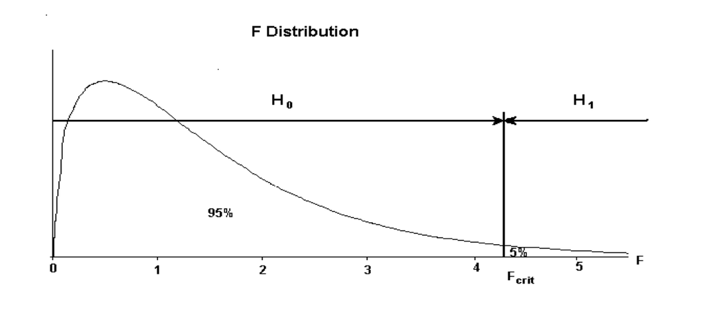

The decision rule can therefore be summarised as:

- If ($F_{calc}$ < $F_{crit}$) $→$ do **not reject** ($H_0$)
- If ($F_{calc}$ > $F_{crit}$) $→$ **reject** ($H_0$)

### 14.3 Stage 3: Sample evidence (use your model)

We now examine the sample evidence obtained from the fitted regression model.

```r
summary(model_hw)
```

```
Call:
lm(formula = Grade_HW ~ HW_minutes, data = hw)

Residuals:
   Min     1Q Median     3Q    Max
-60.86 -40.48 -27.05  42.38  64.30

Coefficients:
             Estimate Std. Error t value Pr(>|t|)
(Intercept) 23.101606   9.630175   2.399   0.0187 *
HW_minutes   0.021261   0.008868   2.398   0.0187 *
---
Signif. codes:  0 '***' 0.001 '**' 0.01 '*' 0.05 '.' 0.1 ' ' 1

Residual standard error: 42.11 on 83 degrees of freedom
Multiple R-squared:  0.06477,   Adjusted R-squared:  0.0535
F-statistic: 5.748 on 1 and 83 DF,  p-value: 0.01875
```

From the regression output we obtain the value of the F-statistic, which measures the relative size of the explained variation compared with the unexplained variation.

For this model the calculated statistic is:

- $F = 5.748$

To apply the decision rule we also need the degrees of freedom of the test:

- $df_1 = 1$ (regression degrees of freedom)
- $df_2 = 83$ (residual degrees of freedom)

Using these degrees of freedom, the critical value of the F distribution at the $5%$ significance level is:

```r
# The critical value corresponds to the 95th percentile of the F distribution with df_1 = 1 and df_2 = 83.
F_crit <- qf(0.95, 1, 83) # the 95th percentile (critical value) of the F distribution
F_crit
```

```
[1] 3.955961
```

$F_{crit} \approx 3.96$

We now compare the calculated value with the critical value:

$F_{calc} = 5.748 \quad > \quad F_{crit} = 3.96$

Therefore, according to the decision rule, we reject the null hypothesis $H_0$.

The calculated F-statistic is larger than the critical value, which means that the variation explained by the regression model is sufficiently large relative to the unexplained variation.

### 14.4 Stage 4: Conclusion

Since

$F_{calc} > F_{crit}$

we reject the null hypothesis $H_0$.

This provides statistical evidence that there is a relationship between homework time and homework grades.

Since the regression model appears to describe a statistically significant relationship, we can now describe the nature of that relationship using the estimated regression equation.

$\hat{Y} = 23.10 + 0.021 HW_{minutes}$

## 15 Describing the Nature of the Relationship

Earlier we asked whether there is evidence of a relationship between homework time and homework grades.

The regression model suggests that such a relationship exists, but it is relatively weak.

The estimated regression equation is

$$\widehat{\text{Grade\_HW}} = 23.10 + 0.021 \times \text{HW\_minutes}$$

The positive slope of the regression line indicates that **as the amount of time spent on homework increases, the predicted homework grade tends to increase**.

However, the value of $R^2 = 0.065$ indicates that this relationship explains only a small proportion of the variation in homework grades.

This suggests that although homework time may influence performance, **many other factors also affect student outcomes**.

**TipThink about it**

What other factors might influence homework grades besides the amount of time spent on homework?

For example, consider:

- prior knowledge of the material
- study strategies
- motivation
- stress levels
- outside commitments

## 16 Using the Model to Make Predictions

One of the main purposes of regression models is to make predictions about the response variable for given values of the explanatory variable.

Using the estimated regression equation

$$\widehat{\text{Grade\_HW}} = 23.10 + 0.021 \times \text{HW\_minutes}$$

we can predict the homework grade for a student who spends a specific amount of time on homework.

Suppose a student spends **120 minutes** on homework.

Substituting this value into the regression equation gives

$$\widehat{\text{Grade\_HW}}
=
23.10 + 0.021 \times 120$$

$$\widehat{\text{Grade\_HW}} \approx 25.6$$

The model therefore predicts that a student who spends **120 minutes on homework** would obtain a homework grade of approximately **25.6**.

```r
23.10 + 0.021 * 120
```

```
[1] 25.62
```

Or we can use `predict()` function.

```r
predict(model_hw,
        newdata = data.frame(HW_minutes = 120))
```

```
       1
25.65292
```

## 17 A Note on Prediction

Regression models are most reliable when used to make predictions **within the range of the observed data**.

If we attempt to make predictions for values of the explanatory variable far outside the range observed in the dataset, the predictions may be unreliable. This situation is known as **extrapolation**.

It is therefore important to examine the range of the explanatory variable before using the regression model for prediction.

```r
summary(hw$HW_minutes)
```

```
   Min. 1st Qu.  Median    Mean 3rd Qu.    Max.
  208.0   629.0   871.0   956.1  1105.0  3255.0
```

## 18 The ANOVA Table

The F-test used above is closely related to the analysis of variance (ANOVA) framework.

We can obtain the ANOVA table in R using:

```r
anova(model_hw)
```

```
Analysis of Variance Table

Response: Grade_HW
           Df Sum Sq Mean Sq F value  Pr(>F)
HW_minutes  1  10192 10191.9  5.7482 0.01875 *
Residuals  83 147164  1773.1
---
Signif. codes:  0 '***' 0.001 '**' 0.01 '*' 0.05 '.' 0.1 ' ' 1
```

The ANOVA table provides another way of presenting the same regression model by separating the variation in the response variable into:

- variation explained by the regression model
- variation left unexplained (the residual variation)

The F-statistic compares these two quantities.

If the explained variation is large relative to the unexplained variation, the regression model is considered statistically significant.

This is exactly the same decomposition introduced earlier:

$$\text{Total Variation}
=
\text{Explained Variation}
+
\text{Unexplained Variation}$$

The F-statistic in the ANOVA table compares the amount of variation explained by the model with the amount left unexplained.

If the explained variation is large relative to the unexplained variation, the F-statistic will be large and the model will be statistically significant.

For our model, the ANOVA table confirms the earlier conclusion from the regression summary: there is statistical evidence of a relationship between homework time and homework grades, although the relationship is relatively weak.

## 19 Summary

In this lecture we applied regression to a real dataset on homework deadlines and student performance.

Our analysis suggests that:

- the relationship between homework time and homework grades is positive
- the relationship is statistically significant
- the relationship is relatively weak, with $R^2 = 0.065$
- homework time explains only a small proportion of the variation in homework grades
- the fitted model can be used to make predictions, although these should be interpreted with caution

This example illustrates an important lesson in regression: a relationship may be statistically significant without explaining a large proportion of the overall variation in the response.

## 20 Your Turn 👉

Using what you have learned in this lecture, try to answer the following questions.

1. What does the positive slope in the regression model suggest about the relationship between homework time and homework grades?
2. The value of $R^2$ in our model is approximately 0.065. What does this tell us about how much variation in homework grades is explained by homework time?
3. The F-test indicated that the relationship is statistically significant. What does this mean in practical terms?
4. Why should we be cautious when using regression models to make predictions outside the range of the observed data?

Think about these questions before the next lecture.